# C2M2: Peer Reviewed Assignment

### Outline:

The objectives for this assignment:

1. Utilize contrasts to see how different pairwise comparison tests can be conducted.
2. Understand power and why it's important to statistical conclusions.
3. Understand the different kinds of post-hoc tests and when they should be used.

General tips:

1. Read the questions carefully to understand what is being asked.
2. This work will be reviewed by another human, so make sure that you are clear and concise in what your explanations and answers.

# Problem 1: Contrasts and Coupons

Consider a hardness testing machine that presses a rod with a pointed tip into a metal specimen with a known force. By measuring the depth of the depression caused by the tip, the hardness of the specimen is determined.

Suppose we wish to determine whether or not four different tips produce different readings on a hardness testing machine. The experimenter has decided to obtain four observations on Rockwell C-scale hardness for each tip. There is only one factor - tip type - and a completely randomized single-factor design would consist of randomly assigning each one of the 4×4=16 runs to an experimental unit, that is, a metal coupon, and observing the hardness reading that results. Thus, 16 different metal test coupons would be required in this experiment, one for each run in the design.

```python
tip    <- factor(rep(1:4, each = 4))
coupon <- factor(rep(1:4, times = 4))
y <- c(9.3, 9.4, 9.6, 10,
       9.4, 9.3, 9.8, 9.9,
       9.2, 9.4, 9.5, 9.7,
       9.7, 9.6, 10, 10.2)
hardness <- data.frame(y, tip, coupon)
hardness
```

A data.frame: 16 × 3

| y <dbl> | tip <fct> | coupon <fct> |
| --- | --- | --- |
| 9.3 | 1 | 1 |
| 9.4 | 1 | 2 |
| 9.6 | 1 | 3 |
| 10.0 | 1 | 4 |
| 9.4 | 2 | 1 |
| 9.3 | 2 | 2 |
| 9.8 | 2 | 3 |
| 9.9 | 2 | 4 |
| 9.2 | 3 | 1 |
| 9.4 | 3 | 2 |
| 9.5 | 3 | 3 |
| 9.7 | 3 | 4 |
| 9.7 | 4 | 1 |
| 9.6 | 4 | 2 |
| 10.0 | 4 | 3 |
| 10.2 | 4 | 4 |

### 1. (a) Visualize the Groups

Before we start throwing math at anything, let's visualize our data to get an idea of what to expect from the eventual results.

Construct interaction plots for `tip` and `coupon` using ggplot(). Be sure to explain what you can from the plots.

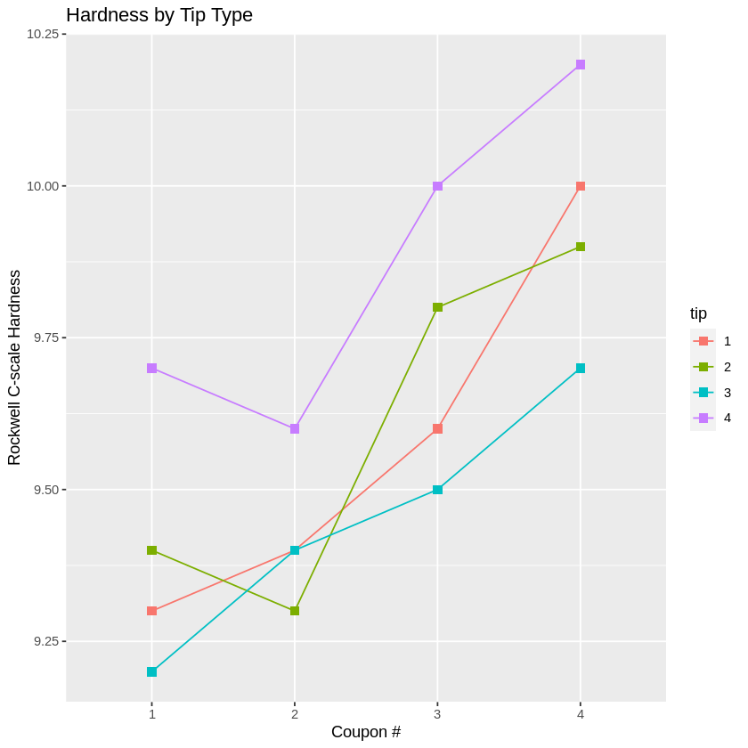

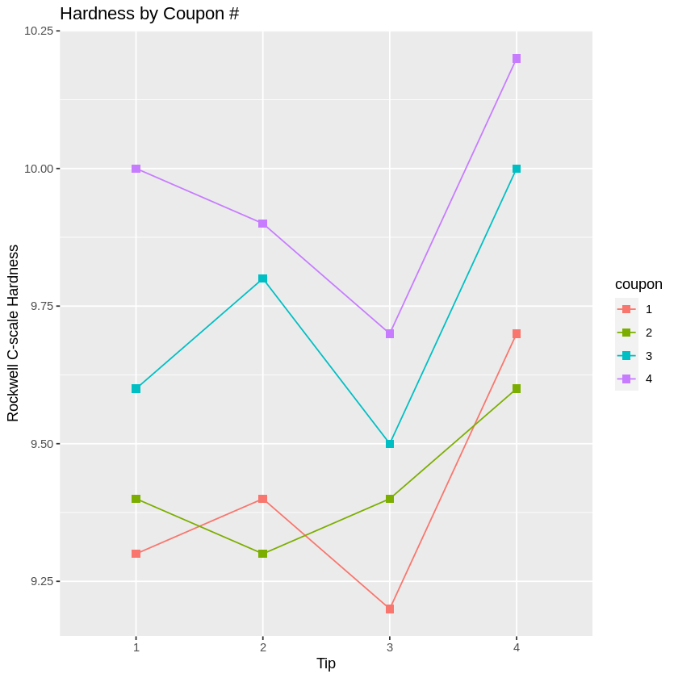

```python
library(ggplot2)

#library(interactions)
#hard_mod <- lm(y ~ tip + coupon + tip:coupon, data = hardness)
#cat_plot(hard_mod, pred = tip, modx = coupon, interval = TRUE)

tip_plot <- ggplot(hardness, aes(x = coupon, y = y, group = tip)) +
    geom_line(aes(color = tip)) +
    geom_point(size = 2.6, aes(color = tip), shape = 15) +
    labs(title = "Hardness by Tip Type",
            x = "Coupon #", y = "Rockwell C-scale Hardness")
tip_plot

coupon_plot <- ggplot(hardness, aes(x = tip, y = y, group = coupon)) +
    geom_line(aes(color = coupon)) +
    geom_point(size = 2.6, aes(color = coupon), shape = 15) +
    labs(title = "Hardness by Coupon #",
            x = "Tip", y = "Rockwell C-scale Hardness")
coupon_plot
```

In the first plot, Tips 1-3 are fairly close together and seem to perform similarly in hardness, but Tip 4 appears to be much harder than the other three regardless of which coupon it was tested on. In the second plot, Coupon 1 and Coupon 2 appear to score similarly in hardness, but Coupon 3 outscores them both by a decent amount on every tip type, and Coupon 4 outscores all three other coupons on every tip type by a noticeable amount. Some of the lines cross over each other and swap positions for which coupon or tip is harder, namely Coupon 1/Coupon 2 and Tip 1/Tip 2/Tip 3, so there could be some interference interaction between the members in each of the bunches of crossing lines.

### 1. (b) Interactions

Should we test for interactions between `tip` and `coupon`? Maybe there is an interaction between the different metals that goes beyond our current scientific understanding!

Fit a linear model to the data with predictors `tip` and `coupon`, and an interaction between the two. Display the summary and explain why (or why not) an interaction term makes sense for this data.

```python
#Leave as factors and get NAs or convert?
#mlr_mod <- lm(y ~ as.numeric(tip) + as.numeric(coupon) + as.numeric(tip):as.numeric(coupon), data = hardness)

mlr_mod <- lm(y ~ tip + coupon + tip:coupon, data = hardness)
summary(mlr_mod)
anova(mlr_mod)
#str(hardness)
```

```
Call:
lm(formula = y ~ tip + coupon + tip:coupon, data = hardness)

Residuals:
ALL 16 residuals are 0: no residual degrees of freedom!

Coefficients:
               Estimate Std. Error t value Pr(>|t|)
(Intercept)   9.300e+00         NA      NA       NA
tip2          1.000e-01         NA      NA       NA
tip3         -1.000e-01         NA      NA       NA
tip4          4.000e-01         NA      NA       NA
coupon2       1.000e-01         NA      NA       NA
coupon3       3.000e-01         NA      NA       NA
coupon4       7.000e-01         NA      NA       NA
tip2:coupon2 -2.000e-01         NA      NA       NA
tip3:coupon2  1.000e-01         NA      NA       NA
tip4:coupon2 -2.000e-01         NA      NA       NA
tip2:coupon3  1.000e-01         NA      NA       NA
tip3:coupon3 -3.758e-15         NA      NA       NA
tip4:coupon3 -3.869e-15         NA      NA       NA
tip2:coupon4 -2.000e-01         NA      NA       NA
tip3:coupon4 -2.000e-01         NA      NA       NA
tip4:coupon4 -2.000e-01         NA      NA       NA

Residual standard error: NaN on 0 degrees of freedom
Multiple R-squared:      1,	Adjusted R-squared:    NaN
F-statistic:   NaN on 15 and 0 DF,  p-value: NA
```

A anova: 4 × 5

|  | Df <int> | Sum Sq <dbl> | Mean Sq <dbl> | F value <dbl> | Pr(>F) <dbl> |
| --- | --- | --- | --- | --- | --- |
| tip | 3 | 0.385 | 0.128333333 | NaN | NaN |
| coupon | 3 | 0.825 | 0.275000000 | NaN | NaN |
| tip:coupon | 9 | 0.080 | 0.008888889 | NaN | NaN |
| Residuals | 0 | 0.000 | NaN | NA | NA |

### 1. (c) Contrasts

Let's take a look at the use of contrasts. Recall that a contrast takes the form

$$\sum_{i=1}^t c_i\mu_i = 0,$$

where $\mathbf{c} = (c_1,...,c_t)$ is a constant vector and $\mathbf{\mu} = (\mu_1,...,\mu_t)$ is a parameter vector (e.g., $\mu_1$ is the mean of the $i^{th}$ group).

We can note that $\mathbf{c} = (1,-1,0,0)$ corresponds to the null hypothesis $H_0: \mu_2 - \mu_1 = 0$, where $\mu_1$ is the mean associated with tip1 and $\mu_2$ is the mean associated with tip2. The code below tests this hypothesis.

Repeat this test for the hypothesis $H_0: \mu_4 - \mu_3 = 0$. Interpret the results. What are your conclusions?

```python
library(multcomp)
lmod = lm(y~tip+coupon, data=hardness)
fit.gh2 = glht(lmod, linfct = mcp(tip = c(1,-1,0,0)))

#estimate of mu_2 - mu_1
with(hardness, sum(y[tip == 2])/length(y[tip == 2]) -
     sum(y[tip == 1])/length(y[tip == 1]))

#new model fit for second null hypothesis
fit = glht(lmod, linfct = mcp(tip = c(0,0,-1,1)))

#estimate of mu_4 - mu_3
with(hardness, sum(y[tip == 4])/length(y[tip == 4]) -
     sum(y[tip == 3])/length(y[tip == 3]))
```

0.0250000000000021

0.425000000000001

In the second null hypothesis calculation with $H_0: \mu_4 - \mu_3$ and $c = (0, 0, -1, 1)$, the estimated difference between $\mu_3$ and $\mu_4$ was found to be ~0.425 units of hardness, indicating that there is probably a significant difference between the mean hardness of tip 3 and tip 4.

In both cases, the p-value for the resulting difference in means should be calculated with inferential t-testing and compared to the pre-selected alpha level to demonstrate rigorous *statistical significance* or not. Industry knowledge should also be sought out to determine whether the differences are *practically siginificant*; as an outsider lacking domain-specific knowledge about hardness testing scales and metallurgy it would be incautious to presume one way or the other.

### 1. (d) All Pairwise Comparisons

What if we want to test all possible pairwise comparisons between treatments. This can be done by setting the treatment factor (`tip`) to "Tukey". Notice that the p-values are adjusted (because we are conducting multiple hypotheses!).

Perform all possible Tukey Pairwise tests. What are your conclusions?

```python
#av <- aov(mlr_mod_tbd) tip = "tukey" is for glht
av <- aov(lm(y ~ tip + coupon))
hsd_test <- TukeyHSD(av)
hsd_test
```

```
  Tukey multiple comparisons of means
    95% family-wise confidence level

Fit: aov(formula = lm(y ~ tip + coupon))

$tip
      diff         lwr        upr     p adj
2-1  0.025 -0.18311992 0.23311992 0.9809005
3-1 -0.125 -0.33311992 0.08311992 0.3027563
4-1  0.300  0.09188008 0.50811992 0.0066583
3-2 -0.150 -0.35811992 0.05811992 0.1815907
4-2  0.275  0.06688008 0.48311992 0.0113284
4-3  0.425  0.21688008 0.63311992 0.0006061

$coupon
     diff         lwr       upr     p adj
2-1 0.025 -0.18311992 0.2331199 0.9809005
3-1 0.325  0.11688008 0.5331199 0.0039797
4-1 0.550  0.34188008 0.7581199 0.0000830
3-2 0.300  0.09188008 0.5081199 0.0066583
4-2 0.525  0.31688008 0.7331199 0.0001200
4-3 0.225  0.01688008 0.4331199 0.0341762
```

Examining the tips, there is statistical evidence based on the Tukey Pairwise test p-values at the $\alpha = 0.05$ family-wise significance level that Tip 4 is different from each of the other three tips. There is not statistical support at the $\alpha = 0.05$ family-wise significance level that Tip 1, Tip 2, and Tip 3 are different from each other.

Examining the coupons, there is statistical evidence based on the Tukey Pairwise test p-values at the $\alpha = 0.05$ family-wise significance level that every coupon is statistically significantly different from every other coupon with the sole exception of Coupon 1 and Coupon 2.

# Problem 2: Ethics in my Math Class!

In your own words, answer the following questions:

- What is power, in the statistical context?
- Why is power important?
- What are potential consequences of ignoring/not including power calculations in statistical analyses?

Statistical power is the probability of correctly rejecting the null hypothesis given that the alternative hypothesis is true. The higher the power of a test, the less likely it is for a Type II error to occur (accepting the null hypothesis when it is false). Power allows researchers to be able to know how effective their experiment or study is at actually being able to detect "effects of substantive interest". Sufficiently powered studies are more likely to ber reproducible; underpowered studies can suffer from ambiguity in their findings because they are unable to be consistently replicated in the future. For example, if a study has a power of 0.15 and correctly rejects the null hypothesis and reports significant results, there are good odds that the next few replications will fail to correctly discern a significant effect occurring (since 85% of the time it will accept the false null hypothesis). Doing power analysis is a great way to determine how many samples are required to meet a particular power requirement (default suggested power is often 0.80), or to determine power ahead of time if you already know how many samples you will have. It is important to calculate power before gathering the data, as post hoc power analysis will lead to flawed values that can overestimate the true power of the study.

# Problem 3: Post-Hoc Tests

There's so many different post-hoc tests! Let's try to understand them better. Answer the following questsions in the markdown cell:

- Why are there multiple post-hoc tests?
- When would we choose to use Tukey's Method over the Bonferroni correction, and vice versa?
- Do some outside research on other post-hoc tests. Explain what the method is and when it would be used.

There are multiple post-hoc tests because there are different objectives that researchers might want to achieve and specific concerns they might want to address. Maybe they need a post-hoc test that is on the conservative side, or maybe one that is on the more powerful side. Some tests are built to deal with conditions such as groups with uneven sample sizes or groups that lack variance homogeneity. Different post-hoc tests are built upon different distributions as well, for example Scheffe's method implements an F-distribution while Tukey's HSD uses SRD (Studentized range distribution).

When running multiple statistical tests, Bonferroni's Correction alters the individual alpha level for each test to ensure a predetermined familywise significance level is maintained. Another post-hoc test called Tukey's HSD (Honest Significant Difference) is used to figure out which pairwise groups in the sample are different from each other and which are the same; Tukey's HSD also corrects for the family-wise significant level like Bonferroni's method. Tukey's HSD would be a good choice to examine all of the pairwise groups, whereas Bonferroni allows the option of picking and choosing which pairs to examine. TukeyHSD tends to outperform Bonferroni on a higher number of means, so Bonferroni is a good choice for examining small number of means. Bonferroni correction is also more conservative than TukeyHSD, so much statistical power is required from the post-hoc test can also be a deciding factor in which of the two tests to facilitate.

Scheffe's Method is a post-hoc test that is strong at comparing "all possible simple and complex pairs of means" and is one of the recommended choices for studies that have unequal sample sizes amongst the groups. Another use case where Scheffe's method can outperform the TukeyHSD would be when many contrasts are potentially of interest and a large number of comparisons of not necessarily a fixed size will be made. The resulting confidence intervals will be narrower and thus more precise using Scheffe's method rather than TukeyHSD.